# hs_post_clean

## minigrid_access_life_improvement

| Feature | Result |
| --- | --- |
| Variable type | character |
| Number of missing obs. | 0 (0 %) |
| Number of unique values | 3 |
| Mode | “yes” |

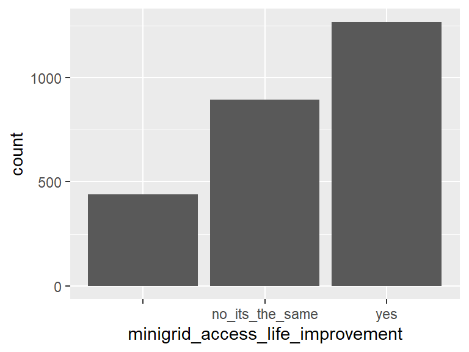

- The following suspected missing value codes enter as regular values: "".

## minigrid_access_productivity_improvement

| Feature | Result |
| --- | --- |
| Variable type | character |
| Number of missing obs. | 0 (0 %) |
| Number of unique values | 1440 |
| Mode | “” |

[figure not shown]

- The following suspected missing value codes enter as regular values: "".
- Note that the following levels have at most five observations: "*(bad_meter", "_its_good", "_no", "ability_to_study_and_do_businesses", "access_in_business", …, "yes_good", "yes_more_productive", "yes_through_presavation_of_some_good_in_fridge_for_later_use", "yes_yes", "yrs" (1413 values omitted).

## minigrid_effect_on_household_female

| Feature | Result |
| --- | --- |
| Variable type | character |
| Number of missing obs. | 0 (0 %) |
| Number of unique values | 1157 |
| Mode | “” |

[figure not shown]

- The following suspected missing value codes enter as regular values: "".
- Note that the following levels have at most five observations: "*(bad_meter", "**we_met_no_one_at_home_all_the_times_we_visited._we_were_told_that_the_occupant_is_dead_and_his_family_members_travelled", "*my_meter_has_been_bad_for_a_while_now_i_have_made_several_complaint_but_i_still_havent_gotten_a_new_meter", "_2", "0ffeten_time", …, "yes_positively.._they_can_now_walk_freely_without_fear", "yes_they_can_cook_and_do_chores_anytime_even_at_night_because_they_use_the_light_to_see", "yes_they_feel_safe_everytime_they_handle_house_chores", "yesit_has_reduced_unnecessary_movement", "yy" (1109 values omitted).

## end_date

| Feature | Result |
| --- | --- |
| Variable type | character |
| Number of missing obs. | 0 (0 %) |
| Number of unique values | 60 |
| Mode | “2022_12_22” |

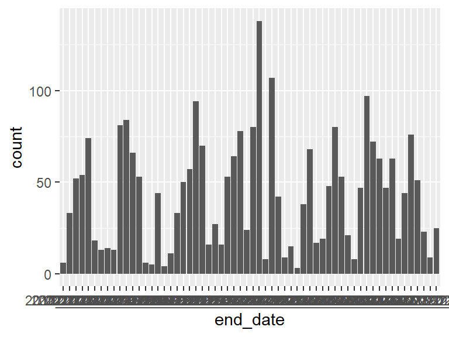

- Note that the following levels have at most five observations: "2022_08_18", "2022_08_20", "2023_02_03".

## customerAccountNumber

| Feature | Result |
| --- | --- |
| Variable type | integer |
| Number of missing obs. | 1483 (56.97 %) |
| Number of unique values | 965 |
| Median | 190118.5 |
| 1st and 3rd quartiles | 151132.75; 224694.25 |
| Min. and max. | 131104; 521042 |

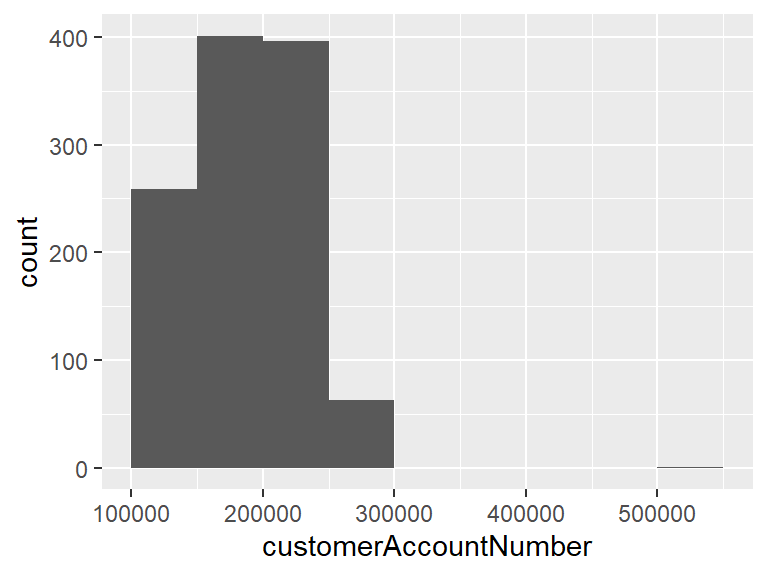

- Note that the following possible outlier values were detected: "521042".

## tariff

| Feature | Result |
| --- | --- |
| Variable type | character |
| Number of missing obs. | 0 (0 %) |
| Number of unique values | 4 |
| Mode | “” |

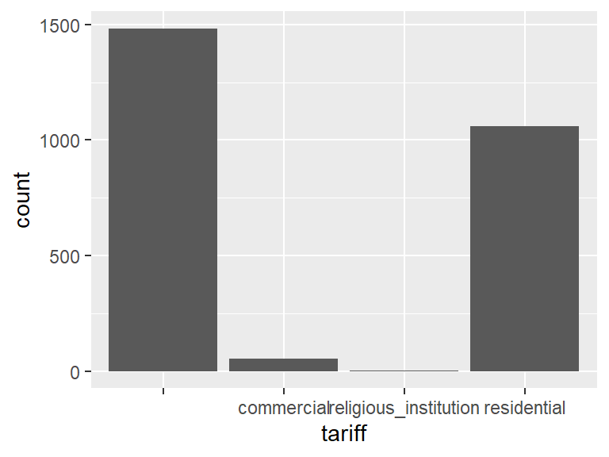

- The following suspected missing value codes enter as regular values: "".
- Note that the following levels have at most five observations: "religious_institution".

## business_owners_count

- Note that this variable is treated as a factor variable below, as it only takes a few unique values.

| Feature | Result |
| --- | --- |
| Variable type | integer |
| Number of missing obs. | 0 (0 %) |
| Number of unique values | 3 |
| Mode | “1” |
| Reference category | 0 |

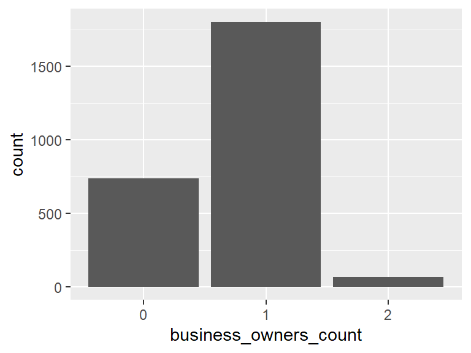

## business_owners_female

- Note that this variable is treated as a factor variable below, as it only takes a few unique values.

| Feature | Result |
| --- | --- |
| Variable type | integer |
| Number of missing obs. | 0 (0 %) |
| Number of unique values | 2 |
| Mode | “0” |
| Reference category | 0 |

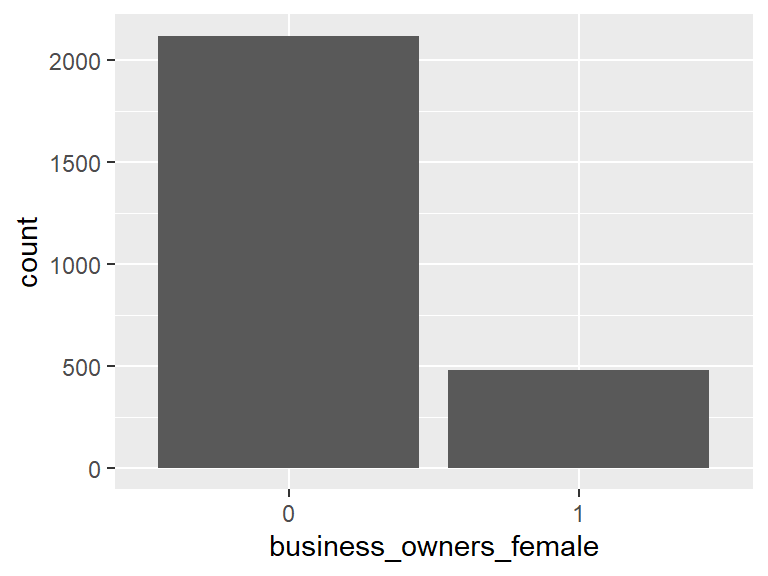

## appliances_addition_count

| Feature | Result |
| --- | --- |
| Variable type | integer |
| Number of missing obs. | 0 (0 %) |
| Number of unique values | 7 |
| Median | 2 |
| 1st and 3rd quartiles | 1; 3 |
| Min. and max. | 1; 7 |

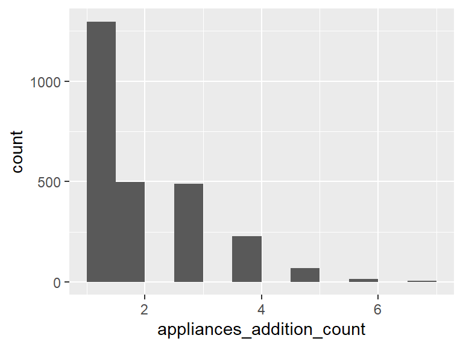

- Note that the following possible outlier values were detected: "7".

Report generation information:

- Created by: Akoua Orsot~ (username: `User`).
- Report creation time: Fri Oct 06 2023 11:42:49
- Report was run from directory: `\\wsl.localhost/Ubuntu/home/aorsot/Renewvia/survey_impact_analysis`
- dataMaid v1.4.1 [Pkg: 2021-10-08 from CRAN (R 4.3.1)]
- R version 4.3.1 (2023-06-16 ucrt).
- Platform: x86_64-w64-mingw32/x64 (64-bit)(Etc/UTC).
- Function call: `makeDataReport(data = hs_post_clean, output = "html", replace = TRUE)`